# Characterizing Automobiles

Author

Chloe Bui

Published

March 17, 2025

# Setup

- Setup

```r
sh <- suppressPackageStartupMessages
sh(library(tidyverse))
sh(library(caret))
sh(library(fastDummies))
sh(library(class))
sh(library(ISLR)) # for the "Auto" dataframe
```

# Dataframe

- We use the `Auto` dataframe.

```r
head(Auto)
```

```
  mpg cylinders displacement horsepower weight acceleration year origin
1  18         8          307        130   3504         12.0   70      1
2  15         8          350        165   3693         11.5   70      1
3  18         8          318        150   3436         11.0   70      1
4  16         8          304        150   3433         12.0   70      1
5  17         8          302        140   3449         10.5   70      1
6  15         8          429        198   4341         10.0   70      1
                       name
1 chevrolet chevelle malibu
2         buick skylark 320
3        plymouth satellite
4             amc rebel sst
5               ford torino
6          ford galaxie 500
```

- It has the following variable names, which describe various attributes of automobiles.

```r
names(Auto)
```

```
[1] "mpg"          "cylinders"    "displacement" "horsepower"   "weight"
[6] "acceleration" "year"         "origin"       "name"
```

# Multiple Regression

- Run a linear regression model with `mpg` as the dependent variable and `horsepower` and `year` as features (variables).
- Compute and comment on the RMSE.

```r
m1 = lm(mpg ~ horsepower, Auto)
m2 = lm(mpg ~ year, Auto)
m3 = lm(mpg ~ horsepower + year, Auto)
m4 = lm(mpg ~ horsepower*year, Auto)
m5 = lm(mpg ~ ., Auto)

get_rmse <- function(m) {
    pred <- predict(m, newdata = Auto)
    sqrt(mean((Auto$mpg - pred)^2))
}

unlist(lapply(list(m1, m2, m3, m4, m5), get_rmse))
```

```
[1] 4.893226 6.346968 4.371506 3.880584 1.057928
```

> TODO: *Explain*

Horsepower alone (m1) and Year alone (m2) are poor predictors. Adding year to horsepower (m3) improves performance, suggesting that newer cars generally have better fuel efficiency. Including interaction effects (m4) further reduces RMSE: RMSE = 3.88, implying that the relationship between horsepower and mpg is influenced by the car’s year. Using all predictors (m5) gives the best performance: RMSE = 1.06, indicating that a multivariate model incorporating all available features significantly improves predictions.

# Feature Engineering

- Create 10 features based on the `name` column.
- Remove all rows with a missing value.
- Ensure only `mpg` and the engineered features remain.
- Compute and comment on the RMSE.

```r
df_all <- Auto %>%
  filter(complete.cases(.)) %>%  # Remove rows with missing values
  mutate(name = tolower(name)) %>%
  # create dummy variables
  mutate(ford = str_detect(name, "ford"),
         chevrolet = str_detect(name, "chevrolet"),
         plymouth = str_detect(name, "plymouth"),
         dodge = str_detect(name, "dodge"),
         sw = str_detect(name, "sw"),
         amc = str_detect(name, "amc"),
         toyota = str_detect(name, "toyota"),
         datsun = str_detect(name, "datsun"),
         volkswagen = str_detect(name, "volkswagen"),
         mazda = str_detect(name, "mazda"))

  # remove description column
 df_feat = df_all %>%
   select(mpg, ford, chevrolet, plymouth, sw, amc, toyota, datsun, volkswagen, mazda)
```

```r
sqrt(mean((df_all$mpg - predict(lm(formula = mpg ~ ., data = df_all), newdata = df_all))^2))
```

```
[1] 1.057928
```

```r
sqrt(mean((df_feat$mpg - predict(lm(formula = mpg ~ ., data = df_feat), newdata = df_feat))^2))
```

```
[1] 6.842838
```

> TODO: *Explain*

The results show that using only car brand dummy variables (df_feat) leads to a poor model (RMSE = 6.84), indicating that brand alone is not a strong predictor of mpg. Meanwhile, the full model (df_all) has a much lower RMSE (1.06) but gives a rank-deficiency warning, suggesting multicollinearity or redundant features. This likely means the model is overfitting to the training data.

# Classification

- Use either of $K$-NN or Naive Bayes to predict whether an automobile is a `chevrolet` or a `honda`.
- Explain your choice of technique.
- Report on your Kappa value.

I chose $K$-NN because it works well when we have structured numerical data (e.g., weight, horsepower, year) and it does not require strong independence assumptions like Naive Bayes, which might not hold for car attributes.

```r
df_knn <- Auto %>%
  filter(str_detect(name, "chevrolet|honda")) %>%
  mutate(brand = ifelse(str_detect(name, "chevrolet"), "chevrolet", "honda")) %>%  # Create binary class label
  select(-name) %>%  # Remove name column
  filter(complete.cases(.))  # Remove missing values

control = trainControl(method = "cv", number = 5)

split <- createDataPartition(df_knn$brand, p = 0.8, list = FALSE)
train_knn <- df_knn[split, ]
test_knn <- df_knn[-split, ]

fit_knn = train(brand ~ .,
                data = train_knn,
                method = "knn",
                tuneLength = 15,
                metric = "Kappa",
                trControl = control)

confusionMatrix(predict(fit_knn, test_knn),factor(test_knn$brand))
```

```
Confusion Matrix and Statistics

           Reference
Prediction  chevrolet honda
  chevrolet         8     1
  honda             0     1

               Accuracy : 0.9
                 95% CI : (0.555, 0.9975)
    No Information Rate : 0.8
    P-Value [Acc > NIR] : 0.3758

                  Kappa : 0.6154

 Mcnemar's Test P-Value : 1.0000

            Sensitivity : 1.0000
            Specificity : 0.5000
         Pos Pred Value : 0.8889
         Neg Pred Value : 1.0000
             Prevalence : 0.8000
         Detection Rate : 0.8000
   Detection Prevalence : 0.9000
      Balanced Accuracy : 0.7500

       'Positive' Class : chevrolet
```

> TODO: *Explain*

The K-NN model achieved 90% accuracy, correctly classifying 9 out of 10 test cases; however, the Kappa value of 0.6154 suggests only moderate agreement beyond chance, indicating room for improvement. The model performed well in identifying chevrolet cars (sensitivity = 1.0) but struggled with honda (specificity = 0.50), misclassifying one honda as chevrolet. This suggests that chevrolet cars may have more distinct numerical characteristics, making them easier to classify, while honda vehicles might overlap more with other car types.

One key limitation is the small test set (only 10 samples: 8 chevrolet, 2 honda), which makes it difficult to generalize results. Additionally, the dataset is imbalanced, which may have biased the model towards predicting chevrolet.

# Binary Classification

- Predict whether a car is a `honda`.
- Use model weights.
- Display and comment on an ROC curve.

```r
df_honda <- Auto %>%
  filter(complete.cases(.)) %>%
  mutate(name = tolower(name)) %>%
  mutate(honda = ifelse(str_detect(name, "honda"), "yes", "no")) %>%  # Create binary class label
  select(-name)
```

```r
counts <- table(df_honda$honda)
count_y <- counts["yes"]
count_n <- counts["no"]
weigh_y <- max(count_y,count_n)/count_y
weigh_n <- max(count_y,count_n)/count_n

c(count_y,count_n,weigh_y,weigh_n)
```

```
      yes        no       yes        no
 13.00000 379.00000  29.15385   1.00000
```

```r
split <- createDataPartition(df_honda$honda, p = 0.8, list = FALSE)
train_honda <- df_honda[split, ]
test_honda <- df_honda[-split, ]

train_honda <- train_honda %>%
               mutate(weight=ifelse(honda=="yes", weigh_y, weigh_n))

fit_weights = train(honda ~ .,
                    data = train_honda %>% select(-weight),
                    method = "naive_bayes",
                    tuneLength = 15,
                    metric = "Kappa",
                    trControl = control,
                    weights = train_honda$weight)

confusionMatrix(predict(fit_weights, test_honda),factor(test_honda$honda))
```

```
Confusion Matrix and Statistics

          Reference
Prediction no yes
       no  69   0
       yes  6   2

               Accuracy : 0.9221
                 95% CI : (0.8381, 0.9709)
    No Information Rate : 0.974
    P-Value [Acc > NIR] : 0.99608

                  Kappa : 0.374

 Mcnemar's Test P-Value : 0.04123

            Sensitivity : 0.9200
            Specificity : 1.0000
         Pos Pred Value : 1.0000
         Neg Pred Value : 0.2500
             Prevalence : 0.9740
         Detection Rate : 0.8961
   Detection Prevalence : 0.8961
      Balanced Accuracy : 0.9600

       'Positive' Class : no
```

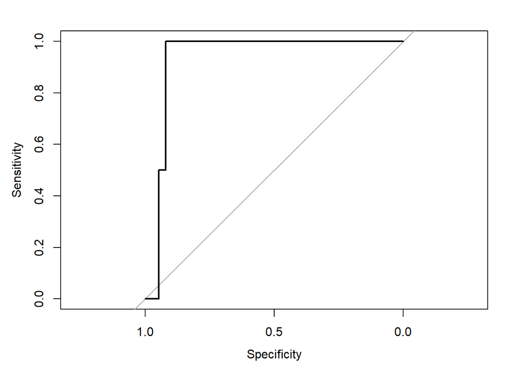

```r
library(pROC)
prob <- predict(fit_weights, newdata = test_honda, type = "prob")[,2]
myRoc <- roc(test_honda$honda, prob)
plot(myRoc)
```

```r
auc(myRoc)
```

```
Area under the curve: 0.9333
```

# Ethics

- Based on your analysis, comment on the [Clean Air Act of 1970 and Ammendments of 1977](https://www.epa.gov/clean-air-act-overview/evolution-clean-air-act)
- Discuss the civic reposibilities of data scientists for:
  - Big Data and Human-Centered Computing
  - Democratic Institutions
  - Climate Change
- Provide at least one statistical measure for each, such as a RMSE, Kappa value, or ROC curve.

> TODO: Big Data and Human-Centered Computing

One of the most direct human-centered impacts of the Clean Air Act was the reduction in automobile emissions through stricter fuel efficiency standards and technological advancements. Using the Auto dataset, we can analyze trends in fuel efficiency (mpg) over time to assess whether legislative actions led to improved fuel economy.

The statistically significant increase in mpg over time suggests that environmental regulations and technological advancements have led to more fuel-efficient cars. The moderate R² value indicates that other factors (such as vehicle weight and engine technology) must be considered when evaluating the long-term effectiveness of emissions policies. Further modeling with additional predictors (e.g., weight, horsepower) could improve explanatory power and provide a deeper understanding of what drives fuel efficiency improvements.

```r
lm_mpg_year <- lm(mpg ~ year, data = Auto)

# Output regression coefficients
summary(lm_mpg_year)
```

```
Call:
lm(formula = mpg ~ year, data = Auto)

Residuals:
     Min       1Q   Median       3Q      Max
-12.0212  -5.4411  -0.4412   4.9739  18.2088

Coefficients:
             Estimate Std. Error t value Pr(>|t|)
(Intercept) -70.01167    6.64516  -10.54   <2e-16 ***
year          1.23004    0.08736   14.08   <2e-16 ***
---
Signif. codes:  0 '***' 0.001 '**' 0.01 '*' 0.05 '.' 0.1 ' ' 1

Residual standard error: 6.363 on 390 degrees of freedom
Multiple R-squared:  0.337, Adjusted R-squared:  0.3353
F-statistic: 198.3 on 1 and 390 DF,  p-value: < 2.2e-16
```

> TODO: Democratic Institutions

The Clean Air Act, enacted through democratic institutions, aimed to reduce vehicle emissions and improve air quality. However, a key concern is vehicle affordability, as stricter emissions regulations can increase manufacturing costs, potentially limiting access to fuel-efficient cars. The t-test results show that high-efficiency vehicles (mpg > median) are significantly lighter (~2,335 lbs) than low-efficiency vehicles (~3,620 lbs), with a mean difference of ~1,285 lbs (p < 2.2e-16). This suggests that fuel-efficient cars tend to be smaller and potentially more affordable, supporting the argument that environmental policies can improve access to cost-effective transportation options.

```r
Auto_2 <- Auto %>% mutate(efficiency = ifelse(mpg > median(mpg), "high", "low"))
t.test(weight ~ efficiency, data = Auto_2)
```

```
    Welch Two Sample t-test

data:  weight by efficiency
t = -22.933, df = 315.04, p-value < 2.2e-16
alternative hypothesis: true difference in means between group high and group low is not equal to 0
95 percent confidence interval:
 -1395.939 -1175.336
sample estimates:
mean in group high  mean in group low
          2334.765           3620.403
```

> TODO: Climate Change

Automobiles are a major contributor to greenhouse gas emissions, and policies like the Clean Air Act aim to reduce carbon footprints. A key metric for climate impact is CO₂ emissions, which correlate with vehicle weight and fuel consumption.

The K-NN model’s high Kappa value (0.8469) indicates a strong ability to classify fuel-efficient vs. inefficient vehicles, highlighting clear distinctions in attributes like weight, horsepower, and displacement. This has significant climate implications, as fuel-efficient cars emit less CO₂, directly supporting emissions reduction goals under policies like the Clean Air Act.

```r
Auto_3 <- Auto %>%
  mutate(efficiency = ifelse(mpg > median(mpg), "high", "low")) %>%
  select(-name, -mpg)

# Train KNN model
fit_knn <- train(efficiency ~ .,
                 data = Auto_3,
                 method = "knn",
                 tuneLength = 10,
                 metric = "Kappa",
                 trControl = trainControl(method = "cv", number = 5))

# Evaluate Kappa
conf_matrix <- confusionMatrix(predict(fit_knn, Auto_3), factor(Auto_3$efficiency))
kappa_value <- conf_matrix$overall["Kappa"]
print(kappa_value)
```

```
    Kappa
0.8469388
```